# Dissertation_Code

This is the code used to pre-process the data in order to evaluate proposed DNN architectures. Due to being written in Jupyter Notebook different parts of the code can be run without needing all of the previous parts to be run as well.

The code was written by Georgios Anyfantis

The first piece of code is used to import the libraries that will be used to pre-process the data and to build the model.

```python
# Importing the libraries

# Libraries used for the preprocessing of the data
from sklearn.preprocessing import PowerTransformer, StandardScaler, LabelEncoder, Normalizer
from imblearn.over_sampling import SMOTE
from imblearn.under_sampling import RandomUnderSampler
from sklearn.feature_selection import SelectKBest, f_classif
from sklearn.model_selection import train_test_split

# Making the graphs
import matplotlib.pyplot as plt

# Data format libraries
import numpy as np
import pandas as pd

# Used for evaluation of the features extracted by ANOVA
# This is done to select the optimum number of features
from sklearn.tree import DecisionTreeClassifier
from sklearn.metrics import accuracy_score

# Neural Networks libraries
from keras.models import Sequential
from keras.layers import Dense, Dropout
from keras.losses import sparse_categorical_crossentropy
import tensorflow as tf

# Used to save Normalizer and PowerTransformer
import joblib

# Metrics used for the evaluation of the models
# The accuracy score is also used but it can be seen further up where
# the libraries for ANOVA, it is used for feature extraction
from sklearn.metrics import recall_score
from sklearn.metrics import multilabel_confusion_matrix
from sklearn.metrics import f1_score
from sklearn.metrics import precision_score

# Libraries used for the construction of the confusion matrix figures
# Pandas and Matplotlib are also used but they are imported further up
import seaborn as sns
```

```python
# Connecting to Google Drive
# This code was used during the training and evaluation period

from google.colab import drive
drive.mount('/content/drive')
```

This library is used to run remove the constant and quasi-constant features. It also allows for reduce of memory usage in pandas by changing the configuration. This is important in order for the computer not to crash.

```python
!pip install fast_ml
# Methods used cleansing constant and quasi-constant features
from fast_ml.utilities import display_all, reduce_memory_usage
from fast_ml.feature_selection import get_constant_features
```

```
     |████████████████████████████████| 42 kB 775 kB/s
```

This part of the code imports all the files that contain the CIC-IDS-2017 dataset. The files are from the MachineLearningCVE. The whole dataset can be downloaded [from here](https://www.unb.ca/cic/datasets/ids-2017.html).

Although, it should be noted that this is the link to the paper published with the dataset. The link for the dataset is at the bottom of that page, web page was last accessed in 28/04/2022.

In this section, the invalid values are detected and the affected rows are removed from the files. Finally, they are concantinated to a larger pandas file that contains the entire dataset.

The files are inputted in chronological order.

```python
list_files = []
# Importing and initial cleansing of the data
# The invalid data is replaced with np.nan
# and then the rows are removed

monday_df = pd.read_csv(r"drive/My Drive/FYP data/Monday-WorkingHours.pcap_ISCX.csv", index_col=None)
monday_df.replace([np.inf, -np.inf, "Infinity", "NaN"], np.nan, inplace=True)
monday_df.dropna(axis="rows", how="any", inplace=True)
list_files.append(monday_df)

tuesday_df = pd.read_csv(r"drive/My Drive/FYP data/Tuesday-WorkingHours.pcap_ISCX.csv", index_col=None)
tuesday_df.replace([np.inf, -np.inf, "Infinity", "NaN"], np.nan, inplace=True)
tuesday_df.dropna(axis="rows", how="any", inplace=True)
list_files.append(tuesday_df)

wednesday_df = pd.read_csv(r"drive/My Drive/FYP data/Wednesday-workingHours.pcap_ISCX.csv", index_col=None)
wednesday_df.replace([np.inf, -np.inf, "Infinity", "NaN"], np.nan, inplace=True)
wednesday_df.dropna(axis="rows", how="any", inplace=True)
list_files.append(wednesday_df)

thursday_morning_df = pd.read_csv(r"drive/My Drive/FYP data/Thursday-WorkingHours-Morning-WebAttacks.pcap_ISCX.csv", index_col=None)
thursday_morning_df.replace([np.inf, -np.inf, "Infinity", "NaN"], np.nan, inplace=True)
thursday_morning_df.dropna(axis="rows", how="any", inplace=True)
list_files.append(thursday_morning_df)

thursday_afternoon_df = pd.read_csv(r"drive/My Drive/FYP data/Thursday-WorkingHours-Afternoon-Infilteration.pcap_ISCX.csv", index_col=None)
thursday_afternoon_df.replace([np.inf, -np.inf, "Infinity", "NaN"], np.nan, inplace=True)
thursday_afternoon_df.dropna(axis="rows", how="any", inplace=True)
list_files.append(thursday_afternoon_df)

friday_morning_df = pd.read_csv(r"drive/My Drive/FYP data/Friday-WorkingHours-Morning.pcap_ISCX.csv", index_col=None)
friday_morning_df.replace([np.inf, -np.inf, "Infinity", "NaN"], np.nan, inplace=True)
friday_morning_df.dropna(axis="rows", how="any", inplace=True)
list_files.append(friday_morning_df)

friday_afternoon_ddos_df = pd.read_csv(r"drive/My Drive/FYP data/Friday-WorkingHours-Afternoon-DDos.pcap_ISCX.csv", index_col=None)
friday_afternoon_ddos_df.replace([np.inf, -np.inf, "Infinity", "NaN"], np.nan, inplace=True)
friday_afternoon_ddos_df.dropna(axis="rows", how="any", inplace=True)
list_files.append(friday_afternoon_ddos_df)

friday_afternoon_port_df = pd.read_csv(r"drive/My Drive/FYP data/Friday-WorkingHours-Afternoon-PortScan.pcap_ISCX.csv", index_col=None)
friday_afternoon_port_df.replace([np.inf, -np.inf, "Infinity", "NaN"], np.nan, inplace=True)
friday_afternoon_port_df.dropna(axis="rows", how="any", inplace=True)
list_files.append(friday_afternoon_port_df)

frame = pd.concat(list_files, axis=0, ignore_index=True)
```

```python
# The pandas frame is then saved in a new CSV file

frame.to_csv('drive/My Drive/FYP data/frame.csv')
```

Removal of constant features is important to not affect the use of ANOVA for feature reduction as it may affect the ranking of the features.

Additionally, these features do not contain any information that can be useful for the model, as all values are constant or they vary very little, thus they may generate noise that can damage the accuracy of the model.

This method finds the features that are constant and returns a list with them.

```python
# Constant features
constant_features = get_constant_features(frame)
constant_features_list = constant_features.query("Desc=='Constant'")['Var'].to_list()
print(constant_features_list)
```

```
[' Bwd PSH Flags', ' Bwd URG Flags', 'Fwd Avg Bytes/Bulk', ' Fwd Avg Packets/Bulk', ' Fwd Avg Bulk Rate', ' Bwd Avg Bytes/Bulk', ' Bwd Avg Packets/Bulk', 'Bwd Avg Bulk Rate']
```

```python
# Similar method to the previous one, main difference is that it removes the all the
# features except the ones in the list
# mainly used for ANOVA feature reduction

def new_dataset(dataset, anova_res):
    train_output = dataset

    for anova_column in range(len(anova_res)):
        print(anova_res[anova_column])
        # Removing the feature from the inputted dataset
        dataset = dataset.drop(anova_res[anova_column], axis=1)

    # Dropping the remaining features
    train_output = train_output.drop(dataset.columns, axis=1)

    return train_output
```

```python
# Method used to remove features that are found on a list
# Primarily used to remove constant and quasi-constant features

def new_dataset_remove(dataset, anova_res):

    for anova_column in range(len(anova_res)):
        print(anova_res[anova_column])
        # Removing the feature from the inputted dataset
        dataset = dataset.drop(anova_res[anova_column], axis=1)

    return dataset
```

```python
# removing constant features
new_frame = new_dataset_remove(frame, constant_features_list)
print(new_frame.columns)
```

```
 Bwd PSH Flags
 Bwd URG Flags
Fwd Avg Bytes/Bulk
 Fwd Avg Packets/Bulk
 Fwd Avg Bulk Rate
 Bwd Avg Bytes/Bulk
 Bwd Avg Packets/Bulk
Bwd Avg Bulk Rate
Index([' Destination Port', ' Flow Duration', ' Total Fwd Packets',
       ' Total Backward Packets', 'Total Length of Fwd Packets',
       ' Total Length of Bwd Packets', ' Fwd Packet Length Max',
       ' Fwd Packet Length Min', ' Fwd Packet Length Mean',
       ' Fwd Packet Length Std', 'Bwd Packet Length Max',
       ' Bwd Packet Length Min', ' Bwd Packet Length Mean',
       ' Bwd Packet Length Std', 'Flow Bytes/s', ' Flow Packets/s',
       ' Flow IAT Mean', ' Flow IAT Std', ' Flow IAT Max', ' Flow IAT Min',
       'Fwd IAT Total', ' Fwd IAT Mean', ' Fwd IAT Std', ' Fwd IAT Max',
       ' Fwd IAT Min', 'Bwd IAT Total', ' Bwd IAT Mean', ' Bwd IAT Std',
       ' Bwd IAT Max', ' Bwd IAT Min', 'Fwd PSH Flags', ' Fwd URG Flags',
       ' Fwd Header Length', ' Bwd Header Length', 'Fwd Packets/s',
       ' Bwd Packets/s', ' Min Packet Length', ' Max Packet Length',
       ' Packet Length Mean', ' Packet Length Std', ' Packet Length Variance',
       'FIN Flag Count', ' SYN Flag Count', ' RST Flag Count',
       ' PSH Flag Count', ' ACK Flag Count', ' URG Flag Count',
       ' CWE Flag Count', ' ECE Flag Count', ' Down/Up Ratio',
       ' Average Packet Size', ' Avg Fwd Segment Size',
       ' Avg Bwd Segment Size', ' Fwd Header Length.1', 'Subflow Fwd Packets',
       ' Subflow Fwd Bytes', ' Subflow Bwd Packets', ' Subflow Bwd Bytes',
       'Init_Win_bytes_forward', ' Init_Win_bytes_backward',
       ' act_data_pkt_fwd', ' min_seg_size_forward', 'Active Mean',
       ' Active Std', ' Active Max', ' Active Min', 'Idle Mean', ' Idle Std',
       ' Idle Max', ' Idle Min', ' Label'],
      dtype='object')
```

Removal of quasi-constant features is important to not affect the ranking dervived from ANOVA for feature reduction.

This method finds the features that are quasi-constant and returns a list with them.

```python
# detecting quasi-constant features
quasi_constant_features_list = constant_features.query("Desc=='Quasi Constant'")['Var'].to_list()
print(quasi_constant_features_list)
```

```
[' Fwd URG Flags', ' CWE Flag Count', ' RST Flag Count', ' ECE Flag Count']
```

```python
# removing quasi-constant featuress
new_frame_final = new_dataset_remove(new_frame, quasi_constant_features_list)
```

```
 Fwd URG Flags
 CWE Flag Count
 RST Flag Count
 ECE Flag Count
```

Saving the frame with the reduced features after removing constant and quasi-constant features.

```python
new_frame_final.to_csv('drive/My Drive/FYP data/cleaned_data.csv')
```

```python
# The difference in number of features with the class of the data
# after removing the constant and quasi-constant features

print(len(new_frame_final.columns))
print(len(frame.columns))
```

```
67
79
```

```python
# Importing the CSV file of the processed data-set.
# This is used in case that the machine needs to be powered off

new_frame_final = pd.read_csv(r"drive/My Drive/FYP data/cleaned_data.csv", index_col="Unnamed: 0")
new_frame_final = reduce_memory_usage(new_frame_final, convert_to_category=False)
```

```python
# Creating the mapping of the encoded labels

le_name_mapping = dict(zip(encoder.classes_, encoder.transform(encoder.classes_)))
print(le_name_mapping)
```

```
{'BENIGN': 0, 'Bot': 1, 'DDoS': 2, 'DoS GoldenEye': 3, 'DoS Hulk': 4, 'DoS Slowhttptest': 5, 'DoS slowloris': 6, 'FTP-Patator': 7, 'Heartbleed': 8, 'Infiltration': 9, 'PortScan': 10, 'SSH-Patator': 11, 'Web Attack � Brute Force': 12, 'Web Attack � Sql Injection': 13, 'Web Attack � XSS': 14}
```

Test-train split is conducted here, the stratify option is used to help split the data evenly.

So all splits have the same amount of classes relative to their size.

```python
X_train, X_test, y_train, y_test = train_test_split(new_frame_final.drop(" Label", axis=1), new_frame_final[" Label"], test_size = 0.2, random_state = 20, stratify=new_frame_final[" Label"])

X_train, X_validation, y_train, y_validation = train_test_split(X_train, y_train, test_size=0.2, random_state=20, stratify=y_train)
```

Here, the data is put into arrays again in order to be used in Pandas data frames. This is important for the next section where data ANOVA feature selection will take place.

```python
train_data = np.c_[X_train, y_train]
test_data = np.c_[X_test, y_test]
validate_data = np.c_[X_validation, y_validation]
```

```python
# Making the Pandas Dataframes

df_train = pd.DataFrame(train_data, columns=new_frame_final.columns)
df_test = pd.DataFrame(test_data, columns=new_frame_final.columns)
df_validation = pd.DataFrame(validate_data, columns=new_frame_final.columns)
```

```python
# Saving the dataframes

df_train.to_csv('drive/My Drive/FYP data/train_data.csv')
df_test.to_csv('drive/My Drive/FYP data/test_data.csv')
df_validation.to_csv('drive/My Drive/FYP data/validation_data.csv')
```

The encoder is constructed here in order to be used for the training of the model used by ANOVA.

This done as the data needs to be transformed in order to be used by the model.

The encoder is also saved in order to be loaded any time it is needed

```python
encoder = LabelEncoder()
encoder.fit(new_frame_final[" Label"])
np.save('drive/My Drive/FYP data/classes.npy', encoder.classes_)
```

```python
# Loading the datasets, mainly used in case the computer was previously
# powered off or the session ended.
# It avoids restarting the process.

df_train = pd.read_csv(r"drive/My Drive/FYP data/train_data.csv", index_col="Unnamed: 0")
df_train = reduce_memory_usage(df_train, convert_to_category=False)

df_test = pd.read_csv(r"drive/My Drive/FYP data/test_data.csv", index_col="Unnamed: 0")
df_test = reduce_memory_usage(df_test, convert_to_category=False)

df_validation = pd.read_csv(r"drive/My Drive/FYP data/validation_data.csv", index_col="Unnamed: 0")
df_validation = reduce_memory_usage(df_validation, convert_to_category=False)

encoder = LabelEncoder()
encoder.classes_ = np.load('drive/My Drive/FYP data/classes.npy', allow_pickle=True)
```

Here the data is being prepared for the ANOVA feature selection. The training data is used to tune the StandardScaler which will be used to prepare the data.

StandardScaler is used as it is very common data normalization algorithm and positively affect the data distribution.

```python
df_train[" Label"] = encoder.transform(df_train[" Label"])
standard = StandardScaler()
y_value_train = standard.fit_transform(df_train.drop(" Label", axis=1))

df_test[" Label"] = encoder.transform(df_test[" Label"])
y_value_test = standard.transform(df_test.drop(" Label", axis=1))

df_validation[" Label"] = encoder.transform(df_validation[" Label"])
y_value_valid = standard.transform(df_validation.drop(" Label", axis=1))
```

```python
# Updating the Pandas DataFrames with the new values after the application
# of StandardScaler

df_train = pd.DataFrame(np.c_[y_value_train, df_train[" Label"]], columns=df_train.columns)
df_train = reduce_memory_usage(df_train, convert_to_category=False)

df_test = pd.DataFrame(np.c_[y_value_test, df_test[" Label"]], columns=df_test.columns)
df_test = reduce_memory_usage(df_test, convert_to_category=False)

df_validation = pd.DataFrame(np.c_[y_value_valid, df_validation[" Label"]], columns=df_validation.columns)
df_validation = reduce_memory_usage(df_validation, convert_to_category=False)
```

```python
# Calculating the ANOVA F-test values
# SelectKBest is trained with the training data and then the other datasets are
# inputted in order to calculate the scores

fs = SelectKBest(score_func=f_classif, k='all')  # k is the number of columns to be returned from this function

y_train = df_train.iloc[:, [-1]]
X_train = df_train.drop(y_train.columns, axis=1)

y_test = df_test.iloc[:, [-1]]
X_test = df_test.drop(y_test.columns, axis=1)

y_valid = df_validation.iloc[:, [-1]]
X_valid = df_validation.drop(y_valid.columns, axis=1)

fs.fit_transform(X_train, y_train.values.ravel())
fs.transform(X_test)
fs.transform(X_valid)
```

```
array([[-4.365e-01, -1.686e-01, -5.859e-03, ..., -1.093e-01,  1.685e-02,
         5.066e-02],
       [-3.391e-01, -4.395e-01, -1.126e-02, ..., -1.093e-01, -3.572e-01,
        -3.394e-01],
       [-4.167e-01, -4.163e-01,  8.955e-04, ..., -1.093e-01, -3.572e-01,
        -3.394e-01],
       ...,
       [-4.365e-01,  2.494e+00, -4.554e-04, ..., -1.093e-01,  3.691e+00,
         3.883e+00],
       [ 1.625e+00, -4.395e-01, -9.911e-03, ..., -1.093e-01, -3.572e-01,
        -3.394e-01],
       [-4.380e-01, -4.043e-01, -4.509e-03, ..., -1.093e-01, -3.572e-01,
        -3.394e-01]], dtype=float16)
```

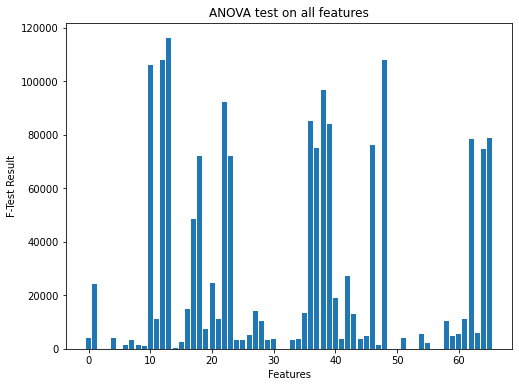

```python
# Printing the results of the ANOVA F-test

plt.bar([i for i in range(len(fs.scores_))], fs.scores_)

plt.title("ANOVA test on all features")
plt.rcParams["figure.figsize"] = (8,6.5)
plt.xlabel("Features")
plt.ylabel("F-Test Result")
plt.savefig('drive/My Drive/FYP data/AllFeatures')
plt.show()
```

The method used to apply ANOVA test and return a different number of features depending the requirements.

```python
def selectKBest(train, test, valid, k):
  sel = SelectKBest(score_func=f_classif, k=k)  # k is the number of columns to be returned from this function

  # preparing the data for the application of ANOVA
  y_train = train.iloc[:, [-1]]
  X_train = train.drop(y_train.columns, axis=1)

  y_test = test.iloc[:, [-1]]
  X_test = test.drop(y_test.columns, axis=1)

  y_valid = valid.iloc[:, [-1]]
  X_valid = valid.drop(y_valid.columns, axis=1)

  # Performing ANOVA F-test
  sel.fit_transform(X_train, y_train.values.ravel())
  sel.transform(X_test)
  sel.transform(X_valid)

  mask = sel.get_support()
  new_features = []  # The list of your K best features

  # creating the list of the selected features
  for bool, feature in zip(mask, train.columns):
    if bool:
      new_features.append(feature)

  return new_features
```

Testing the values for using the 10 most important features.

The datasets were normalized previously and in the case that the experimentation for the selecting the correct number of features is to be performed, the data normalization should be performed again. Using the code that was previously used.

```python
features_10 = selectKBest(df_train, df_test, df_validation, 10)
```

```python
print(features_10)
```

```
['Bwd Packet Length Max', ' Bwd Packet Length Mean', ' Bwd Packet Length Std', ' Fwd IAT Std', ' Max Packet Length', ' Packet Length Std', ' Packet Length Variance', ' Avg Bwd Segment Size', 'Idle Mean', ' Idle Min']
```

```python
# Datasets are being prepared for training and evaluating of the Decision tree
# used to evaluate the number of features selected

y_train = df_train[" Label"]
x_train = new_dataset(df_train, features_10)

y_test = df_test[" Label"]
x_test = new_dataset(df_test, features_10)
```

```
Bwd Packet Length Max
 Bwd Packet Length Mean
 Bwd Packet Length Std
 Fwd IAT Std
 Max Packet Length
 Packet Length Std
 Packet Length Variance
 Avg Bwd Segment Size
Idle Mean
 Idle Min
Bwd Packet Length Max
 Bwd Packet Length Mean
 Bwd Packet Length Std
 Fwd IAT Std
 Max Packet Length
 Packet Length Std
 Packet Length Variance
 Avg Bwd Segment Size
Idle Mean
 Idle Min
```

```python
# Training the DecisionTreeClassifier and evaluating its accuracy
# Used to see how good the number of features perform and if that number
# of features should be selected

tree = DecisionTreeClassifier()
tree.fit(x_train, y_train)

y_test_pred = tree.predict(x_test)
# evaluate predictions
accuracy = accuracy_score(y_test, y_test_pred)
print('Accuracy: %.5f' % (accuracy*100))
```

```
Accuracy: 96.13474
```

Testing the values for using the 15 most important features

```python
features_15 = selectKBest(df_train, df_test, df_validation, 15)
```

```python
# Datasets are being prepared for training and evaluating of the Decision tree
# used to evaluate the number of features selected

y_train_15 = df_train[" Label"]
x_train_15 = new_dataset(df_train, features_15)

y_test_15 = df_test[" Label"]
x_test_15 = new_dataset(df_test, features_15)
```

```
Bwd Packet Length Max
 Bwd Packet Length Mean
 Bwd Packet Length Std
 Flow IAT Max
 Fwd IAT Std
 Fwd IAT Max
 Max Packet Length
 Packet Length Mean
 Packet Length Std
 Packet Length Variance
 Average Packet Size
 Avg Bwd Segment Size
Idle Mean
 Idle Max
 Idle Min
Bwd Packet Length Max
 Bwd Packet Length Mean
 Bwd Packet Length Std
 Flow IAT Max
 Fwd IAT Std
 Fwd IAT Max
 Max Packet Length
 Packet Length Mean
 Packet Length Std
 Packet Length Variance
 Average Packet Size
 Avg Bwd Segment Size
Idle Mean
 Idle Max
 Idle Min
```

```python
# Training the DecisionTreeClassifier and evaluating its accuracy
# Used to see how good the number of features perform and if that number
# of features should be selected

tree = DecisionTreeClassifier()
tree.fit(x_train_15, y_train_15)

y_test_pred_15 = tree.predict(x_test_15)
# evaluate predictions
accuracy = accuracy_score(y_test_15, y_test_pred_15)
print('Accuracy: %.5f' % (accuracy*100))
```

```
Accuracy: 97.48133
```

Testing the values for using the 20 most important features

```python
features_20 = selectKBest(df_train, df_test, df_validation, 20)
```

```python
# Datasets are being prepared for training and evaluating of the Decision tree
# used to evaluate the number of features selected

y_train_20 = df_train[" Label"]
x_train_20 = new_dataset(df_train, features_20)

y_test_20 = df_test[" Label"]
x_test_20 = new_dataset(df_test, features_20)
```

```
 Flow Duration
Bwd Packet Length Max
 Bwd Packet Length Mean
 Bwd Packet Length Std
 Flow IAT Std
 Flow IAT Max
Fwd IAT Total
 Fwd IAT Std
 Fwd IAT Max
 Max Packet Length
 Packet Length Mean
 Packet Length Std
 Packet Length Variance
FIN Flag Count
 PSH Flag Count
 Average Packet Size
 Avg Bwd Segment Size
Idle Mean
 Idle Max
 Idle Min
 Flow Duration
Bwd Packet Length Max
 Bwd Packet Length Mean
 Bwd Packet Length Std
 Flow IAT Std
 Flow IAT Max
Fwd IAT Total
 Fwd IAT Std
 Fwd IAT Max
 Max Packet Length
 Packet Length Mean
 Packet Length Std
 Packet Length Variance
FIN Flag Count
 PSH Flag Count
 Average Packet Size
 Avg Bwd Segment Size
Idle Mean
 Idle Max
 Idle Min
```

```python
# Training the DecisionTreeClassifier and evaluating its accuracy
# Used to see how good the number of features perform and if that number
# of features should be selected

tree = DecisionTreeClassifier()
tree.fit(x_train_20, y_train_20)

y_test_pred_20 = tree.predict(x_test_20)
# evaluate predictions
accuracy = accuracy_score(y_test_20, y_test_pred_20)
print((accuracy*100))
```

```
97.51916630125747
```

Testing the values for using the 25 most important features

```python
features_25 = selectKBest(df_train, df_test, df_validation, 25)
```

```python
# Datasets are being prepared for training and evaluating of the Decision tree
# used to evaluate the number of features selected

y_train_25 = df_train[" Label"]
x_train_25 = new_dataset(df_train, features_25)

y_test_25 = df_test[" Label"]
x_test_25 = new_dataset(df_test, features_25)
```

```
 Flow Duration
Bwd Packet Length Max
 Bwd Packet Length Min
 Bwd Packet Length Mean
 Bwd Packet Length Std
 Flow IAT Mean
 Flow IAT Std
 Flow IAT Max
Fwd IAT Total
 Fwd IAT Std
 Fwd IAT Max
 Bwd IAT Std
 Min Packet Length
 Max Packet Length
 Packet Length Mean
 Packet Length Std
 Packet Length Variance
FIN Flag Count
 PSH Flag Count
 ACK Flag Count
 Average Packet Size
 Avg Bwd Segment Size
Idle Mean
 Idle Max
 Idle Min
 Flow Duration
Bwd Packet Length Max
 Bwd Packet Length Min
 Bwd Packet Length Mean
 Bwd Packet Length Std
 Flow IAT Mean
 Flow IAT Std
 Flow IAT Max
Fwd IAT Total
 Fwd IAT Std
 Fwd IAT Max
 Bwd IAT Std
 Min Packet Length
 Max Packet Length
 Packet Length Mean
 Packet Length Std
 Packet Length Variance
FIN Flag Count
 PSH Flag Count
 ACK Flag Count
 Average Packet Size
 Avg Bwd Segment Size
Idle Mean
 Idle Max
 Idle Min
```

```python
# Training the DecisionTreeClassifier and evaluating its accuracy
# Used to see how good the number of features perform and if that number
# of features should be selected

tree = DecisionTreeClassifier()
tree.fit(x_train_25, y_train_25)

y_test_pred_25 = tree.predict(x_test_25)
# evaluate predictions
accuracy = accuracy_score(y_test_25, y_test_pred_25)
print((accuracy*100))
```

```
97.52977495509003
```

Testing the values for using the 30 most important features

```python
features_30 = selectKBest(df_train, df_test, df_validation, 30)
```

```python
# Datasets are being prepared for training and evaluating of the Decision tree
# used to evaluate the number of features selected

y_train_30 = df_train[" Label"]
x_train_30 = new_dataset(df_train, features_30)

y_test_30 = df_test[" Label"]
x_test_30 = new_dataset(df_test, features_30)
```

```
 Flow Duration
Bwd Packet Length Max
 Bwd Packet Length Min
 Bwd Packet Length Mean
 Bwd Packet Length Std
 Flow IAT Mean
 Flow IAT Std
 Flow IAT Max
 Flow IAT Min
Fwd IAT Total
 Fwd IAT Mean
 Fwd IAT Std
 Fwd IAT Max
 Bwd IAT Std
 Bwd IAT Max
 Min Packet Length
 Max Packet Length
 Packet Length Mean
 Packet Length Std
 Packet Length Variance
FIN Flag Count
 PSH Flag Count
 ACK Flag Count
 Average Packet Size
 Avg Bwd Segment Size
Active Mean
 Active Min
Idle Mean
 Idle Max
 Idle Min
 Flow Duration
Bwd Packet Length Max
 Bwd Packet Length Min
 Bwd Packet Length Mean
 Bwd Packet Length Std
 Flow IAT Mean
 Flow IAT Std
 Flow IAT Max
 Flow IAT Min
Fwd IAT Total
 Fwd IAT Mean
 Fwd IAT Std
 Fwd IAT Max
 Bwd IAT Std
 Bwd IAT Max
 Min Packet Length
 Max Packet Length
 Packet Length Mean
 Packet Length Std
 Packet Length Variance
FIN Flag Count
 PSH Flag Count
 ACK Flag Count
 Average Packet Size
 Avg Bwd Segment Size
Active Mean
 Active Min
Idle Mean
 Idle Max
 Idle Min
```

```python
# Training the DecisionTreeClassifier and evaluating its accuracy
# Used to see how good the number of features perform and if they should be
# selected

tree = DecisionTreeClassifier()
tree.fit(x_train_30, y_train_30)

y_test_pred_30 = tree.predict(x_test_30)
# evaluate predictions
accuracy = accuracy_score(y_test_30, y_test_pred_30)
print((accuracy*100))
```

```
97.78261453809921
```

Testing the values for using the 35 most important features

```python
features_35 = selectKBest(df_train, df_test, df_validation, 35)
```

```python
# Datasets are being prepared for training and evaluating of the Decision tree
# used to evaluate the number of features selected

y_train_35 = df_train[" Label"]
x_train_35 = new_dataset(df_train, features_35)

y_test_35 = df_test[" Label"]
x_test_35 = new_dataset(df_test, features_35)
```

```
 Flow Duration
Bwd Packet Length Max
 Bwd Packet Length Min
 Bwd Packet Length Mean
 Bwd Packet Length Std
 Flow IAT Mean
 Flow IAT Std
 Flow IAT Max
 Flow IAT Min
Fwd IAT Total
 Fwd IAT Mean
 Fwd IAT Std
 Fwd IAT Max
 Bwd IAT Mean
 Bwd IAT Std
 Bwd IAT Max
 Min Packet Length
 Max Packet Length
 Packet Length Mean
 Packet Length Std
 Packet Length Variance
FIN Flag Count
 PSH Flag Count
 ACK Flag Count
 Average Packet Size
 Avg Bwd Segment Size
Init_Win_bytes_forward
Active Mean
 Active Std
 Active Max
 Active Min
Idle Mean
 Idle Std
 Idle Max
 Idle Min
 Flow Duration
Bwd Packet Length Max
 Bwd Packet Length Min
 Bwd Packet Length Mean
 Bwd Packet Length Std
```

[output cut: 15 more lines]

```
 Packet Length Variance
FIN Flag Count
 PSH Flag Count
 ACK Flag Count
 Average Packet Size
 Avg Bwd Segment Size
Init_Win_bytes_forward
Active Mean
 Active Std
 Active Max
 Active Min
Idle Mean
 Idle Std
 Idle Max
 Idle Min
```

```python
# Training the DecisionTreeClassifier and evaluating its accuracy
# Used to see how good the number of features perform and if that number
# of features should be selected

tree = DecisionTreeClassifier()
tree.fit(x_train_35, y_train_35)

y_test_pred_35 = tree.predict(x_test_35)
# evaluate predictions
accuracy = accuracy_score(y_test_35, y_test_pred_35)
print((accuracy*100))
```

```
99.76254296504801
```

Testing the values for using the 36 most important features.

After the evaluation 36 was the number of features that was selected.

```python
features_36 = selectKBest(df_train, df_test, df_validation, 36)
```

```python
# Code used to save the 36 most important features

import pickle

with open("drive/My Drive/FYP data/feature_36.txt", "w") as f:
    for s in features_36:
        f.write(s +"\n")
```

```python
# Datasets are being prepared for training and evaluating of the Decision tree
# used to evaluate the number of features selected

y_train_36 = df_train[" Label"]
x_train_36 = new_dataset(df_train, features_36)

y_test_36 = df_test[" Label"]
x_test_36 = new_dataset(df_test, features_36)
```

```
 Flow Duration
Bwd Packet Length Max
 Bwd Packet Length Min
 Bwd Packet Length Mean
 Bwd Packet Length Std
 Flow IAT Mean
 Flow IAT Std
 Flow IAT Max
 Flow IAT Min
Fwd IAT Total
 Fwd IAT Mean
 Fwd IAT Std
 Fwd IAT Max
 Bwd IAT Mean
 Bwd IAT Std
 Bwd IAT Max
 Min Packet Length
 Max Packet Length
 Packet Length Mean
 Packet Length Std
 Packet Length Variance
FIN Flag Count
 PSH Flag Count
 ACK Flag Count
 Down/Up Ratio
 Average Packet Size
 Avg Bwd Segment Size
Init_Win_bytes_forward
Active Mean
 Active Std
 Active Max
 Active Min
Idle Mean
 Idle Std
 Idle Max
 Idle Min
 Flow Duration
Bwd Packet Length Max
 Bwd Packet Length Min
 Bwd Packet Length Mean
```

[output cut: 17 more lines]

```
FIN Flag Count
 PSH Flag Count
 ACK Flag Count
 Down/Up Ratio
 Average Packet Size
 Avg Bwd Segment Size
Init_Win_bytes_forward
Active Mean
 Active Std
 Active Max
 Active Min
Idle Mean
 Idle Std
 Idle Max
 Idle Min
```

```python
# Training the DecisionTreeClassifier and evaluating its accuracy
# Used to see how good the number of features perform and if they should be
# selected

tree = DecisionTreeClassifier()
tree.fit(x_train_36, y_train_36)

y_test_pred_36 = tree.predict(x_test_36)
# evaluate predictions
accuracy = accuracy_score(y_test_36, y_test_pred_36)
print((accuracy*100))
```

```
99.79030227590987
```

Testing the values for using the 38 most important features

```python
features_38 = selectKBest(df_train, df_test, df_validation, 38)
```

```python
# Datasets are being prepared for training and evaluating of the Decision tree
# used to evaluate the number of features selected

y_train_38 = df_train[" Label"]
x_train_38 = new_dataset(df_train, features_38)

y_test_38 = df_test[" Label"]
x_test_38 = new_dataset(df_test, features_38)
```

```
 Destination Port
 Flow Duration
Bwd Packet Length Max
 Bwd Packet Length Min
 Bwd Packet Length Mean
 Bwd Packet Length Std
 Flow IAT Mean
 Flow IAT Std
 Flow IAT Max
 Flow IAT Min
Fwd IAT Total
 Fwd IAT Mean
 Fwd IAT Std
 Fwd IAT Max
 Bwd IAT Mean
 Bwd IAT Std
 Bwd IAT Max
 Min Packet Length
 Max Packet Length
 Packet Length Mean
 Packet Length Std
 Packet Length Variance
FIN Flag Count
 PSH Flag Count
 ACK Flag Count
 Down/Up Ratio
 Average Packet Size
 Avg Bwd Segment Size
 Subflow Fwd Bytes
Init_Win_bytes_forward
Active Mean
 Active Std
 Active Max
 Active Min
Idle Mean
 Idle Std
 Idle Max
 Idle Min
 Destination Port
 Flow Duration
```

[output cut: 21 more lines]

```
 PSH Flag Count
 ACK Flag Count
 Down/Up Ratio
 Average Packet Size
 Avg Bwd Segment Size
 Subflow Fwd Bytes
Init_Win_bytes_forward
Active Mean
 Active Std
 Active Max
 Active Min
Idle Mean
 Idle Std
 Idle Max
 Idle Min
```

```python
# Training the DecisionTreeClassifier and evaluating its accuracy
# Used to see how good the number of features perform and if that number
# of features should be selected

tree = DecisionTreeClassifier()
tree.fit(x_train_38, y_train_38)

y_test_pred_38 = tree.predict(x_test_38)
# evaluate predictions
accuracy = accuracy_score(y_test_38, y_test_pred_38)
print((accuracy*100))
```

```
99.85695998415774
```

Testing the values for using the 40 most important features

```python
features_40 = selectKBest(df_train, df_test, df_validation, 40)
```

```python
# Datasets are being prepared for training and evaluating of the Decision tree
# used to evaluate the number of features selected

y_train_40 = df_train[" Label"]
x_train_40 = new_dataset(df_train, features_40)

y_test_40 = df_test[" Label"]
x_test_40 = new_dataset(df_test, features_40)
```

```
 Destination Port
 Flow Duration
Total Length of Fwd Packets
Bwd Packet Length Max
 Bwd Packet Length Min
 Bwd Packet Length Mean
 Bwd Packet Length Std
 Flow IAT Mean
 Flow IAT Std
 Flow IAT Max
 Flow IAT Min
Fwd IAT Total
 Fwd IAT Mean
 Fwd IAT Std
 Fwd IAT Max
 Bwd IAT Mean
 Bwd IAT Std
 Bwd IAT Max
 Min Packet Length
 Max Packet Length
 Packet Length Mean
 Packet Length Std
 Packet Length Variance
FIN Flag Count
 PSH Flag Count
 ACK Flag Count
 URG Flag Count
 Down/Up Ratio
 Average Packet Size
 Avg Bwd Segment Size
 Subflow Fwd Bytes
Init_Win_bytes_forward
Active Mean
 Active Std
 Active Max
 Active Min
Idle Mean
 Idle Std
 Idle Max
 Idle Min
```

[output cut: 25 more lines]

```
 ACK Flag Count
 URG Flag Count
 Down/Up Ratio
 Average Packet Size
 Avg Bwd Segment Size
 Subflow Fwd Bytes
Init_Win_bytes_forward
Active Mean
 Active Std
 Active Max
 Active Min
Idle Mean
 Idle Std
 Idle Max
 Idle Min
```

```python
# Training the DecisionTreeClassifier and evaluating its accuracy
# Used to see how good the number of features perform and if that number
# of features should be selected

tree = DecisionTreeClassifier()
tree.fit(x_train_40, y_train_40)

y_test_pred_40 = tree.predict(x_test_40)
# evaluate predictions
accuracy = accuracy_score(y_test_40, y_test_pred_40)
print((accuracy*100))
```

```
99.85925852582146
```

Testing the values for using the 42 most important features

```python
features_42 = selectKBest(df_train, df_test, df_validation, 42)
```

```python
# Datasets are being prepared for training and evaluating of the Decision tree
# used to evaluate the number of features selected

y_train_42 = df_train[" Label"]
x_train_42 = new_dataset(df_train, features_42)

y_test_42 = df_test[" Label"]
x_test_42 = new_dataset(df_test, features_42)
```

```
 Destination Port
 Flow Duration
Total Length of Fwd Packets
Bwd Packet Length Max
 Bwd Packet Length Min
 Bwd Packet Length Mean
 Bwd Packet Length Std
 Flow IAT Mean
 Flow IAT Std
 Flow IAT Max
 Flow IAT Min
Fwd IAT Total
 Fwd IAT Mean
 Fwd IAT Std
 Fwd IAT Max
 Bwd IAT Mean
 Bwd IAT Std
 Bwd IAT Max
 Bwd Packets/s
 Min Packet Length
 Max Packet Length
 Packet Length Mean
 Packet Length Std
 Packet Length Variance
FIN Flag Count
 SYN Flag Count
 PSH Flag Count
 ACK Flag Count
 URG Flag Count
 Down/Up Ratio
 Average Packet Size
 Avg Bwd Segment Size
 Subflow Fwd Bytes
Init_Win_bytes_forward
Active Mean
 Active Std
 Active Max
 Active Min
Idle Mean
 Idle Std
```

[output cut: 29 more lines]

```
 ACK Flag Count
 URG Flag Count
 Down/Up Ratio
 Average Packet Size
 Avg Bwd Segment Size
 Subflow Fwd Bytes
Init_Win_bytes_forward
Active Mean
 Active Std
 Active Max
 Active Min
Idle Mean
 Idle Std
 Idle Max
 Idle Min
```

```python
# Training the DecisionTreeClassifier and evaluating its accuracy
# Used to see how good the number of features perform and if that number
# of features should be selected

tree = DecisionTreeClassifier()
tree.fit(x_train_42, y_train_42)

y_test_pred_42 = tree.predict(x_test_42)
# evaluate predictions
accuracy = accuracy_score(y_test_42, y_test_pred_42)
print((accuracy*100))
```

```
99.8254876444545
```

Testing the values for using the 45 most important features

```python
features_45 = selectKBest(df_train, df_test, df_validation, 45)
```

```python
# Datasets are being prepared for training and evaluating of the Decision tree
# used to evaluate the number of features selected

y_train_45 = df_train[" Label"]
x_train_45 = new_dataset(df_train, features_45)

y_test_45 = df_test[" Label"]
x_test_45 = new_dataset(df_test, features_45)
```

```
 Destination Port
 Flow Duration
Total Length of Fwd Packets
 Fwd Packet Length Min
Bwd Packet Length Max
 Bwd Packet Length Min
 Bwd Packet Length Mean
 Bwd Packet Length Std
 Flow IAT Mean
 Flow IAT Std
 Flow IAT Max
 Flow IAT Min
Fwd IAT Total
 Fwd IAT Mean
 Fwd IAT Std
 Fwd IAT Max
 Bwd IAT Mean
 Bwd IAT Std
 Bwd IAT Max
 Bwd IAT Min
Fwd PSH Flags
 Bwd Packets/s
 Min Packet Length
 Max Packet Length
 Packet Length Mean
 Packet Length Std
 Packet Length Variance
FIN Flag Count
 SYN Flag Count
 PSH Flag Count
 ACK Flag Count
 URG Flag Count
 Down/Up Ratio
 Average Packet Size
 Avg Bwd Segment Size
 Subflow Fwd Bytes
Init_Win_bytes_forward
Active Mean
 Active Std
 Active Max
```

[output cut: 35 more lines]

```
 ACK Flag Count
 URG Flag Count
 Down/Up Ratio
 Average Packet Size
 Avg Bwd Segment Size
 Subflow Fwd Bytes
Init_Win_bytes_forward
Active Mean
 Active Std
 Active Max
 Active Min
Idle Mean
 Idle Std
 Idle Max
 Idle Min
```

```python
# Training the DecisionTreeClassifier and evaluating its accuracy
# Used to see how good the number of features perform and if that number
# of features should be selected

tree = DecisionTreeClassifier()
tree.fit(x_train_45, y_train_45)

y_test_pred_45 = tree.predict(x_test_45)
# evaluate predictions
accuracy = accuracy_score(y_test_45, y_test_pred_45)
print((accuracy*100))
```

```
99.82601807714613
```

The performance of all features that are available

```python
# Evaluating of using all the features after removing constant
# and quasi-constant features

tree = DecisionTreeClassifier()
tree.fit(df_train.drop([' Label'], axis=1), df_train[' Label'])

y_test_pred_all = tree.predict(df_test.drop([' Label'], axis=1))
# evaluate predictions
accuracy = accuracy_score(y_test_pred_all, df_test[' Label'])
print((accuracy*100))
```

```
99.84599770853077
```

```python
# Importing the list of 36 features that will be used to clean the data set and
# prepare it for testing
# It should be noted that this is done in case that the computer was closed and
# the list needs to be re-imported

import pickle
features_36 = []

with open(r"drive/My Drive/FYP data/feature_36.txt", "r") as f:
  for line in f:
    features_36.append(str(line.strip()))
```

```python
# Method used to ensure that the name is the feature file
# to match the ones in the dataframes
# as to ensure feature reduction is performed

def correct_names(columns, orig):
  col = []
  for m in range(len(orig)):
    for n in range(len(columns)):
      if columns[n].replace(" ", "") == orig[m].replace(" ", ""):
        col.append(columns[m])

  return col
```

```python
# Loading all the datasets before the application of feature reduction and SMOTE

df_train_vanila = pd.read_csv(r"drive/My Drive/FYP data/train_data.csv", index_col="Unnamed: 0")
df_train_vanila = reduce_memory_usage(df_train_vanila, convert_to_category=False)

df_test_vanilla = pd.read_csv(r"drive/My Drive/FYP data/test_data.csv", index_col="Unnamed: 0")
df_train_vanila = reduce_memory_usage(df_test_vanilla, convert_to_category=False)

df_validation_vanilla = pd.read_csv(r"drive/My Drive/FYP data/validation_data.csv", index_col="Unnamed: 0")
df_validation_vanilla = reduce_memory_usage(df_validation_vanilla, convert_to_category=False)

# Loading the encoder that will be used
encoder = LabelEncoder()
encoder.classes_ = np.load('drive/My Drive/FYP data/classes.npy', allow_pickle=True)
```

```python
# Loading training dataset before ANOVA and SMOTE application
# Used in cases where the computer needed to be powered off

df_train_vanila = pd.read_csv(r"drive/My Drive/FYP data/train_data.csv", index_col="Unnamed: 0")
df_train_vanila = reduce_memory_usage(df_train_vanila, convert_to_category=False)
```

```python
# Transforming the data for sampling

df_train_vanila[" Label"] = encoder.transform(df_train_vanila[" Label"])
```

[output not shown]

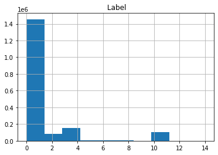

```python
# It should be noted that the histogram is created in order to see how many
# instances of each attack occur and help guide the sampling strategy

df_train_vanila.hist(column=" Label")
```

```python
# The values per attack

print(df_train_vanila[" Label"].value_counts())
```

```
0     1453644
4      147279
10     101634
2       81936
3        6587
7        5078
11       3774
6        3710
5        3519
1        1252
12        965
14        418
9          23
13         14
8           7
Name:  Label, dtype: int64
```

```python
# Resample strategy for SMOTE to ensure that the number of classes are equal and
# can fit in the case of batch_size=32

resample_values = {4:147296, 10:147296, 2:147296, 3:147296, 7:147296, 11:147296, 6:147296, 5:147296, 1:147296, 12:147296, 14:147296, 9:147296, 13:147296, 8:147296}
```

```python
# Correcting the names of the features to be used for the dataset reduction

features = correct_names(df_validation_vanilla.columns,features_36)
```

```python
# Performing feature reduction to the Validation dataset

y_valid = df_validation_vanilla[" Label"]
x_valid = new_dataset(df_validation_vanilla, features)
```

```
 Destination Port
 Flow Duration
 Total Fwd Packets
 Total Backward Packets
Total Length of Fwd Packets
 Total Length of Bwd Packets
 Fwd Packet Length Max
 Fwd Packet Length Min
 Fwd Packet Length Mean
 Fwd Packet Length Std
Bwd Packet Length Max
 Bwd Packet Length Min
 Bwd Packet Length Mean
 Bwd Packet Length Std
Flow Bytes/s
 Flow Packets/s
 Flow IAT Mean
 Flow IAT Std
 Flow IAT Max
 Flow IAT Min
Fwd IAT Total
 Fwd IAT Mean
 Fwd IAT Std
 Fwd IAT Max
 Fwd IAT Min
Bwd IAT Total
 Bwd IAT Mean
 Bwd IAT Std
 Bwd IAT Max
 Bwd IAT Min
Fwd PSH Flags
 Fwd Header Length
 Bwd Header Length
Fwd Packets/s
 Bwd Packets/s
 Min Packet Length
```

```python
# Encoding the validation dataset labels

y_valid = encoder.transform(y_valid)
```

```python
# Preparing the columns for the new Pandas Dataframe that will save the reduced
# features data

columns = x_valid.columns.to_list()
columns.append(' Label')
```

```python
# Saving the reduced dataset in CSV format

df_validation = pd.DataFrame(np.c_[x_valid, y_valid], columns=columns)
df_validation = reduce_memory_usage(df_validation, convert_to_category=False)
df_validation.to_csv("drive/My Drive/FYP data/validation_data.csv")
```

```python
# Performing feature reduction to the Training dataset

y_train_36_SMOTE = df_train_vanila[" Label"]
x_train_36_SMOTE = new_dataset(df_train_vanila, features)
```

```
 Destination Port
 Flow Duration
 Total Fwd Packets
 Total Backward Packets
Total Length of Fwd Packets
 Total Length of Bwd Packets
 Fwd Packet Length Max
 Fwd Packet Length Min
 Fwd Packet Length Mean
 Fwd Packet Length Std
Bwd Packet Length Max
 Bwd Packet Length Min
 Bwd Packet Length Mean
 Bwd Packet Length Std
Flow Bytes/s
 Flow Packets/s
 Flow IAT Mean
 Flow IAT Std
 Flow IAT Max
 Flow IAT Min
Fwd IAT Total
 Fwd IAT Mean
 Fwd IAT Std
 Fwd IAT Max
 Fwd IAT Min
Bwd IAT Total
 Bwd IAT Mean
 Bwd IAT Std
 Bwd IAT Max
 Bwd IAT Min
Fwd PSH Flags
 Fwd Header Length
 Bwd Header Length
Fwd Packets/s
 Bwd Packets/s
 Min Packet Length
```

```python
# Optimizing performance of the resulting datarame for SMOTE application

x_train_36_SMOTE = reduce_memory_usage(x_train_36_SMOTE, convert_to_category=False)
```

```python
# Performing SMOTE, setting up the method to perform the oversampling as it should

oversample = SMOTE(sampling_strategy=resample_values, k_neighbors=4,random_state=42)

new_X_train, y_train= oversample.fit_resample(x_train_36_SMOTE, y_train_36_SMOTE)
```

```python
# Performing the undersampling on the dataset in order to achieve a good ratio
# between the majority class and minority classes

under = RandomUnderSampler(sampling_strategy={0:750016},random_state=42)

new_X_train_under, y_train_under= under.fit_resample(new_X_train, y_train)
```

```python
# Preparing columns for the new dataframe that will be used to save and keep
# the data after sampling
# This is done as it is easier to handle data in Pandas

print(x_train_36_SMOTE.columns)
columns = x_train_36_SMOTE.columns.to_list()
columns.append(' Label')
```

```
Index([' Destination Port', ' Flow Duration', ' Total Fwd Packets',
       ' Total Backward Packets', 'Total Length of Fwd Packets',
       ' Total Length of Bwd Packets', ' Fwd Packet Length Max',
       ' Fwd Packet Length Min', ' Fwd Packet Length Mean',
       ' Fwd Packet Length Std', 'Bwd Packet Length Max',
       ' Bwd Packet Length Min', ' Bwd Packet Length Mean',
       ' Bwd Packet Length Std', 'Flow Bytes/s', ' Flow Packets/s',
       ' Flow IAT Mean', ' Flow IAT Std', ' Flow IAT Max', ' Flow IAT Min',
       'Fwd IAT Total', ' Fwd IAT Mean', ' Fwd IAT Std', ' Fwd IAT Max',
       ' Fwd IAT Min', 'Bwd IAT Total', ' Bwd IAT Mean', ' Bwd IAT Std',
       ' Bwd IAT Max', ' Bwd IAT Min', 'Fwd PSH Flags', ' Fwd Header Length',
       ' Bwd Header Length', 'Fwd Packets/s', ' Bwd Packets/s',
       ' Min Packet Length'],
      dtype='object')
```

```python
# Creating the new dataframe that will have the new data after sampling
# It is saved in case that the computer needs to be powered off

df_oversampled = pd.DataFrame(np.c_[new_X_train_under, y_train_under], columns=columns)
df_oversampled = reduce_memory_usage(df_oversampled, convert_to_category=False)
df_oversampled.to_csv("drive/My Drive/FYP data/oversampled_training_data.csv")
```

The classes and the number of occurences after sampling. This is important as it shows the number of attacks per class and helps calculate the ratio.

```python
print(df_oversampled[" Label"].value_counts())
```

```
0.0     750016
1.0     147296
2.0     147296
3.0     147296
4.0     147296
5.0     147296
6.0     147296
7.0     147296
8.0     147296
9.0     147296
10.0    147296
11.0    147296
12.0    147296
13.0    147296
14.0    147296
Name:  Label, dtype: int64
```

```python
# Loading the training dataset after sampling in case that the computer needs to
# be restarted

df_oversampled = pd.read_csv(r"drive/My Drive/FYP data/oversampled_training_data.csv", index_col="Unnamed: 0")
df_oversampled = reduce_memory_usage(df_oversampled, convert_to_category=False)
```

```python
# Number of features with the label after sampling and feature selection

print(len(df_oversampled.columns))
```

```
37
```

```python
# correcting the number of feature columns to be removed

features = correct_names(df_test.columns,features_36)
```

```python
# Loading the encoder to encode the labels for the test dataset

encoder = LabelEncoder()
encoder.classes_ = np.load('drive/My Drive/FYP data/classes.npy', allow_pickle=True)
df_test_vanilla[" Label"] = encoder.transform(df_test_vanilla[" Label"])
```

```python
x_test_less = new_dataset(df_test_vanilla, features)
```

```python
# Preparing columns for the Pandas dataframe that will contain the data for
# the test dataset

columns = x_test_less.columns.to_list()
columns.append(' Label')
```

```python
# Creating the test dataset dataframe and optimising it
# Saving the test dataset in case the computer needs tobe powered off or the session is lost

df_test = pd.DataFrame(np.c_[x_test_less, df_test_vanilla[" Label"]], columns=columns)
df_test = reduce_memory_usage(df_test, convert_to_category=False)
df_test.to_csv("drive/My Drive/FYP data/test_data.csv")
```

This is the initial architecture that was tested, the following steps are the function that creates the model, its training and evaluation.

```python
# The method used to create the initial architecture,
# All layers are seen in the method with their respective values
# These are reflected in the figure in the Appendix

def create_baseline():
	model = Sequential()
	model.add(Dense(128, input_dim=36, activation='relu'))
	model.add(Dropout(0.2))
	model.add(Dense(64, activation='relu'))
	model.add(Dropout(0.2))
	model.add(Dense(32, activation='relu'))
	model.add(Dropout(0.2))
	model.add(Dense(16, activation='softmax'))
	model.compile(loss='sparse_categorical_crossentropy', optimizer='adam', metrics=['accuracy'])
	return model
```

```python
# Making the model and showing its total parameters as well as the parameteres
# per layer

model_v1 = create_baseline()
model_v1.summary()
```

```
Model: "sequential"
_________________________________________________________________
 Layer (type)                Output Shape              Param #
=================================================================
 dense (Dense)               (None, 128)               4736

 dropout (Dropout)           (None, 128)               0

 dense_1 (Dense)             (None, 64)                8256

 dropout_1 (Dropout)         (None, 64)                0

 dense_2 (Dense)             (None, 32)                2080

 dropout_2 (Dropout)         (None, 32)                0

 dense_3 (Dense)             (None, 16)                528

=================================================================
Total params: 15,600
Trainable params: 15,600
Non-trainable params: 0
_________________________________________________________________
```

```python
# Performing data normalization to the data to be inputted

normalizer = Normalizer()
standardizer = PowerTransformer(method='yeo-johnson')

# The training dataset is used to prepare the Normalizer and PowerTransformer
X_train = normalizer.fit_transform(df_oversampled.drop(' Label', axis=1))
X_train = standardizer.fit_transform(X_train)

X_test = normalizer.transform(df_test.drop(' Label', axis=1))
X_test = standardizer.transform(X_test)
```

```python
# Saving the Normalizer and Transformer for feature use

normalizer_filename = "drive/My Drive/FYP data/normalizer.save"
joblib.dump(normalizer, normalizer_filename)

standardizer_filename = "drive/My Drive/FYP data/standardizer.save"
joblib.dump(standardizer, standardizer_filename)
```

```python
# Callbacks used to help training go as planned, to avoid overfitting and to
# help with training if the learning plateaus

# Used to avoid overfitting by checking the loss function of the test
# dataset. Once overitting is detected training stops and the weights
# from the epoch with the best loss are restore
early_stop = tf.keras.callbacks.EarlyStopping(monitor='val_loss',
                        min_delta=0,
                        patience=5,
                        verbose=1,
                        restore_best_weights=True)

# Used to avoid overfitting by checking the accuracy of the test dataset
early_stop_accuracy = tf.keras.callbacks.EarlyStopping(monitor='val_accuracy',
                        min_delta=0,
                        patience=5,
                        verbose=1,
                        restore_best_weights=True)

# Reducing the learning parameter if a Plateau is detected
reduce_lr = tf.keras.callbacks.ReduceLROnPlateau(monitor='val_accuracy',
                                patience=3,
                                verbose=1,
                                factor=0.2,
                                min_lr=1e-6)
```

```python
# Training the model, the inputted data is the training dataset,
# Testing dataset is used to see how well the training is going
# Batch size is 32 and 25 epochs will be used for training

model_v1.fit(X_train, df_oversampled[' Label'], epochs=25, batch_size=32, verbose=1, validation_data=(X_test, df_test[' Label']), callbacks=[early_stop, reduce_lr, early_stop_accuracy])
```

```
Epoch 10: ReduceLROnPlateau reducing learning rate to 0.00020000000949949026.
Epoch 21: ReduceLROnPlateau reducing learning rate to 4.0000001899898055e-05.
```

```
<keras.callbacks.History at 0x7fc41a375690>
```

```python
# Saving the trained model

model_v1.save('drive/My Drive/FYP data/keras_model_v1_2.h5')
```

```python
# Loading the validation dataset for the validation of the performance of the model

df_validation = pd.read_csv(r"drive/My Drive/FYP data/validation_data.csv", index_col="Unnamed: 0")
df_validation = reduce_memory_usage(df_validation, convert_to_category=False)
```

```python
# Importing the PowerTransformer and Normalizer configuration files to prepare
# the validation dataset

normalizer = Normalizer()
standardizer = PowerTransformer(method='yeo-johnson')

normalizer = joblib.load('drive/My Drive/FYP data/normalizer.save')
standardizer = joblib.load('drive/My Drive/FYP data/standardizer.save')
```

```python
# Loading the model in case it is needed
# Usually done if the session has been terminated or the computer has been powered off

model_v1 = tf.keras.models.load_model('drive/My Drive/FYP data/keras_model_v1_2.h5')
```

```python
# Preparing the validation dataset by transforming its data

X_valid = normalizer.transform(df_validation.drop(' Label', axis=1))
X_valid = standardizer.transform(X_valid)
```

```python
# Performing the prediction with the validation dataset.

y_pred = model_v1.predict(X_valid)

# Due to the nature of Soft-Max to return probabilities of prediction
# This method is employed to select the class with the largest prediction
y_pred = np.argmax(y_pred, axis=-1)
```

```python
# Calculating the acurracy and recall scores

print(accuracy_score(df_validation[' Label'], y_pred))
print(recall_score(df_validation[' Label'], y_pred, average='macro'))
print(recall_score(df_validation[' Label'], y_pred, average='micro'))
print(recall_score(df_validation[' Label'], y_pred, average='weighted'))
```

```
0.9760045086858506
0.8636721519805375
0.9760045086858506
0.9760045086858506
```

```python
# Calculating the conffusion matrix for each class

array_multi = multilabel_confusion_matrix(df_validation[' Label'], y_pred)
```

```python
# Method used to print the confusion matrices of each class
# Code modified from https://stackoverflow.com/questions/62722416/plot-confusion-matrix-for-multilabel-classifcation-python

def print_confusion_matrices(confusion_matrix, axes, class_label, class_names, fontsize=14):

    # Creating a dataframe with the confusion matrix of each class
    df_confusion = pd.DataFrame(
        confusion_matrix, index=class_names, columns=class_names,
    )

    # Generating the heatmaps for each value of the confusion matrix
    # of the inputted class
    try:
        heat_map = sns.heatmap(df_confusion, annot=True, fmt="d", cbar=False, ax=axes)
    except ValueError:
        raise ValueError("Confusion matrix values must be integers.")

    heat_map.yaxis.set_ticklabels(heat_map.yaxis.get_ticklabels(), rotation=0, ha='right', fontsize=fontsize)
    heat_map.xaxis.set_ticklabels(heat_map.xaxis.get_ticklabels(), rotation=45, ha='right', fontsize=fontsize)
    axes.set_ylabel('True label')
    axes.set_xlabel('Predicted label')
    axes.set_title("Confusion Matrix for the class - " + class_label)
```

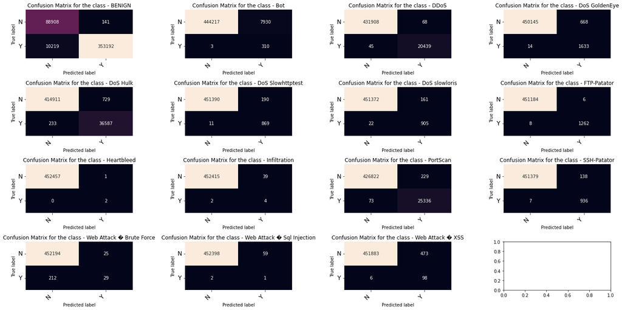

```python
# The data is being prepared for the confusion matrices generation.
# Code modified from https://stackoverflow.com/questions/62722416/plot-confusion-matrix-for-multilabel-classifcation-python

vis_arr = np.asarray(array_multi)

classes = encoder.classes_

labels = ["".join(classes[i]) for i in range(len(encoder.classes_))]

fig, ax = plt.subplots(4, 4, figsize=(20, 10))

# Generetting the confusion matrices
for axes, cf_matrix, label in zip(ax.flatten(), vis_arr, labels):
    print_confusion_matrices(cf_matrix, axes, label, ["N", "Y"])

fig.tight_layout()
# Saving the matrices for use in the Report
plt.savefig('drive/My Drive/FYP data/confusion_matrix_model1.png')
plt.show()
```

```python
# Calculating the F1-Score of the initial architecture

print(f1_score(df_validation[' Label'], y_pred, average='macro'))
print(f1_score(df_validation[' Label'], y_pred, average='micro'))
print(f1_score(df_validation[' Label'], y_pred, average='weighted'))
```

```
0.6715157010931585
0.9760045086858506
0.9844421004961078
```

```python
# Calculating the precision score of the initial architecture

print(precision_score(df_validation[' Label'], y_pred, average='macro'))
print(precision_score(df_validation[' Label'], y_pred, average='micro'))
print(precision_score(df_validation[' Label'], y_pred, average='weighted'))
print(precision_score(df_validation[' Label'], y_pred, average=None))
```

```
0.64909712094758
0.9760045086858506
0.9943175692427727
[0.99960094 0.03762136 0.99668406 0.70969144 0.98046414 0.82058546
 0.84896811 0.99526814 0.66666667 0.09302326 0.99104244 0.87150838
 0.53703704 0.01666667 0.17162872]
```

```python
# Installing the library used to calculate specificity

!pip install aif360
```

```
     |████████████████████████████████| 175 kB 8.7 MB/s
     |████████████████████████████████| 564 kB 58.4 MB/s
```

```python
# Calculating specificity for the initial architecture

from aif360.sklearn.metrics import specificity_score

specificity_score(df_validation[' Label'], y_pred, sample_weight=None)
```

```
0.9824614561193594
```

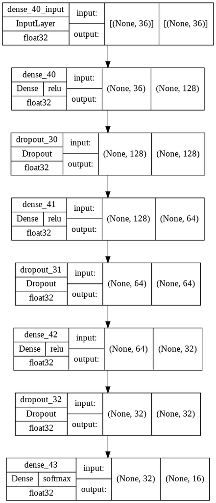

```python
# Generating the figure that shows the way the initial architecture is structured

tf.keras.utils.plot_model(model_v1,show_shapes=True,
    show_dtype=True,expand_nested=True,show_layer_activations=True, to_file='drive/My Drive/FYP data/model_v1.png')
```

This is the second architecture that was tested, the following steps are the function that creates the model, its training and evaluation.

```python
# The method used to create the second architecture,
# All layers are seen in the method with their respective values
# These are reflected in the figure in the Appendix

def create_baseline_2():
	model = Sequential()
	model.add(Dense(256, input_dim=36, activation='relu'))
	model.add(Dropout(0.2))
	model.add(Dense(128, activation='relu'))
	model.add(Dropout(0.2))
	model.add(Dense(64, activation='relu'))
	model.add(Dropout(0.2))
	model.add(Dense(32, activation='softmax'))
	model.compile(loss='sparse_categorical_crossentropy', optimizer='adam', metrics=['accuracy'])
	return model
```

```python
# Creating the Model for the second architecture and training it
# The parameters of the model can be seen

model_v2 = create_baseline_2()
model_v2.summary()

# Training the model, the inputted data is the training dataset,
# Testing dataset is used to see how well the training is going
# Batch size is 32 and 25 epochs will be used for training

model_v2.fit(X_train, df_oversampled[' Label'], epochs=25, batch_size=32, verbose=1, validation_data=(X_test, df_test[' Label']), callbacks=[early_stop, reduce_lr, early_stop_accuracy])
```

```
Model: "sequential_1"
_________________________________________________________________
 Layer (type)                Output Shape              Param #
=================================================================
 dense_4 (Dense)             (None, 256)               9472

 dropout_3 (Dropout)         (None, 256)               0

 dense_5 (Dense)             (None, 128)               32896

 dropout_4 (Dropout)         (None, 128)               0

 dense_6 (Dense)             (None, 64)                8256

 dropout_5 (Dropout)         (None, 64)                0

 dense_7 (Dense)             (None, 32)                2080

=================================================================
Total params: 52,704
Trainable params: 52,704
Non-trainable params: 0
_________________________________________________________________
Epoch 18: ReduceLROnPlateau reducing learning rate to 0.00020000000949949026.
Epoch 22: ReduceLROnPlateau reducing learning rate to 4.0000001899898055e-05.
Epoch 24: early stopping
```

```
<keras.callbacks.History at 0x7f171aaee510>
```

```python
# Saving the trained model of the second architecture

model_v2.save('drive/My Drive/FYP data/keras_model_v2.h5')
```

```python
# Loading the second architecture model
# This is mainly done in case the computer powers off or the session is closed

model_v2 = tf.keras.models.load_model('drive/My Drive/FYP data/keras_model_v2.h5')
```

```python
# Performing prediction with the validation dataset
# This data will be used to calculate the evaluation metrics

y_pred_2 = model_v2.predict(X_valid)

# Due to the nature of Soft-Max, probabilities of the output being in a class is used
# This method selects the class with the largest probability
y_pred_2 = np.argmax(y_pred_2, axis=-1)
```

```python
# Calculating the accuracy and the Recall

print(accuracy_score(df_validation[' Label'], y_pred_2))
print(recall_score(df_validation[' Label'], y_pred_2, average='macro'))
print(recall_score(df_validation[' Label'], y_pred_2, average='micro'))
print(recall_score(df_validation[' Label'], y_pred_2, average='weighted'))
```

```
0.973546832869204
0.906110995971226
0.973546832869204
0.973546832869204
```

```python
# Producing a multi-label confussin martix for the classes

array_multi_2 = multilabel_confusion_matrix(df_validation[' Label'], y_pred_2)
```

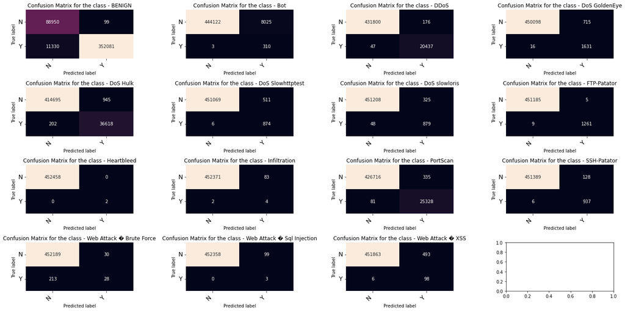

```python
# Producing the confusion matrix figure with the multi-class conffusion matrix
# Code modified from https://stackoverflow.com/questions/62722416/plot-confusion-matrix-for-multilabel-classifcation-python

vis_arr = np.asarray(array_multi_2)

classes = encoder.classes_

labels = ["".join(classes[i]) for i in range(len(encoder.classes_))]

fig, axis = plt.subplots(4, 4, figsize=(20, 10))

# Generating the confuion martices for each class
for axes, cf_matrix, label in zip(axis.flatten(), vis_arr, labels):
    print_confusion_matrices(cf_matrix, axes, label, ["N", "Y"])

fig.tight_layout()
plt.savefig('drive/My Drive/FYP data/confusion_matrix_model2.png')
plt.show()
```

```python
# Calculating the F1-Score for the second architecture

print(f1_score(df_validation[' Label'], y_pred_2, average='macro'))
print(f1_score(df_validation[' Label'], y_pred_2, average='micro'))
print(f1_score(df_validation[' Label'], y_pred_2, average='weighted'))
```

```
0.6653722821803396
0.973546832869204
0.9823320059861764
```

```python
# Calculating the Precision score for the second architecture

print(precision_score(df_validation[' Label'], y_pred_2, average='macro'))
print(precision_score(df_validation[' Label'], y_pred_2, average='micro'))
print(precision_score(df_validation[' Label'], y_pred_2, average='weighted'))
```

```
0.6430887799121925
0.973546832869204
0.9928133422565407
```

```python
# Calculating the specificity score for the second architecture

from aif360.sklearn.metrics import specificity_score

specificity_score(df_validation[' Label'], y_pred_2, sample_weight=None)
```

```
0.9822513474600075
```

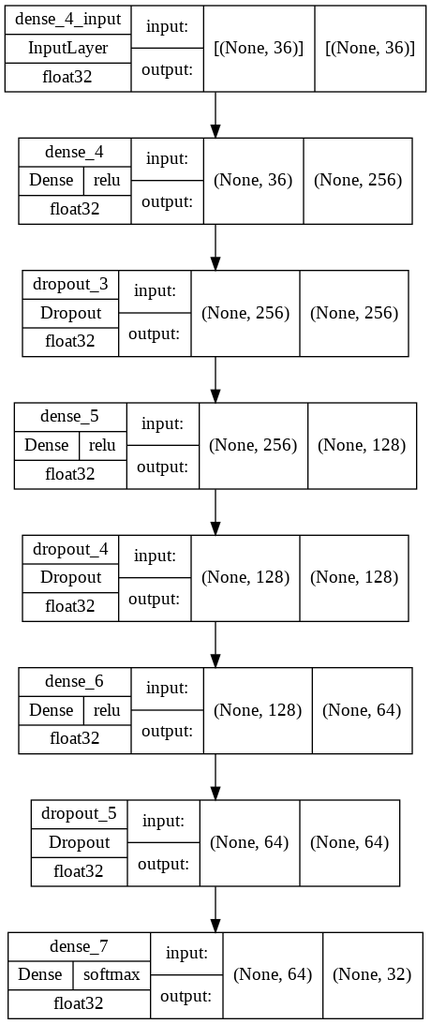

```python
# Creating and saving the figure that shows the structure of the proposed architecture
# The figure can be ound in the appendix of the report

tf.keras.utils.plot_model(model_v2,show_shapes=True,
    show_dtype=True,expand_nested=True,show_layer_activations=True, to_file='drive/My Drive/FYP data/model_v2.png')
```

This is the third architecture that was used.

The following section is the training as due to its bad performance it was not evaluated further.

```python
# The method used to construct the third architecture tested

def create_baseline_3():
	model = Sequential()
	model.add(Dense(256, input_dim=36, activation='relu'))
	model.add(Dropout(0.2))
	model.add(Dense(64, activation='relu'))
	model.add(Dropout(0.2))
	model.add(Dense(32, activation='relu'))
	model.add(Dropout(0.2))
	model.add(Dense(16, activation='relu'))
	model.add(Dropout(0.2))
	model.compile(loss='sparse_categorical_crossentropy', optimizer='adam', metrics=['accuracy'])
	return model
```

```python
# Creating the model of the third architecture

model_v3 = create_baseline_3()
model_v3.summary()
```

```
Model: "sequential_1"
_________________________________________________________________
 Layer (type)                Output Shape              Param #
=================================================================
 dense_5 (Dense)             (None, 256)               9472

 dropout_4 (Dropout)         (None, 256)               0

 dense_6 (Dense)             (None, 64)                16448

 dropout_5 (Dropout)         (None, 64)                0

 dense_7 (Dense)             (None, 32)                2080

 dropout_6 (Dropout)         (None, 32)                0

 dense_8 (Dense)             (None, 16)                528

 dropout_7 (Dropout)         (None, 16)                0

=================================================================
Total params: 28,528
Trainable params: 28,528
Non-trainable params: 0
_________________________________________________________________
```

```python
# Training the third architecture
# Training the model, the inputted data is the training dataset,
# Testing dataset is used to see how well the training is going
# Batch size is 32 and 25 epochs will be used for training

model_v3.fit(X_train, df_oversampled[' Label'], epochs=25, batch_size=32, verbose=1, validation_data=(X_test, df_test[' Label']), callbacks=[early_stop, reduce_lr, early_stop_accuracy])
```

```
Epoch 4: ReduceLROnPlateau reducing learning rate to 0.00020000000949949026.
Restoring model weights from the end of the best epoch: 1.
Epoch 6: early stopping
Epoch 6: early stopping
```

```
<keras.callbacks.History at 0x7f84e9d7cb50>
```

The fourth architecture is being created and evaluated in this section.

The training and the evaluation using the chosen metrics can be seen in this section.

```python
# The method used to create the model for the fourth architecture
# All the layers and their values can be seen below

def create_baseline_4():
	model = Sequential()
	model.add(Dense(256, input_dim=36, activation='relu'))
	model.add(Dropout(0.2))
	model.add(Dense(128, activation='relu'))
	model.add(Dropout(0.2))
	model.add(Dense(64, activation='relu'))
	model.add(Dropout(0.2))
	model.add(Dense(32, activation='relu'))
	model.add(Dropout(0.2))
	model.add(Dense(16, activation='softmax'))
	model.compile(loss='sparse_categorical_crossentropy', optimizer='adam', metrics=['accuracy'])
	return model
```

```python
# Creating the model from the fourth architecture
# And outputting the structure of the layers and their parameters

model_v4 = create_baseline_4()
model_v4.summary()
```

```
Model: "sequential_2"
_________________________________________________________________
 Layer (type)                Output Shape              Param #
=================================================================
 dense_9 (Dense)             (None, 256)               9472

 dropout_8 (Dropout)         (None, 256)               0

 dense_10 (Dense)            (None, 128)               32896

 dropout_9 (Dropout)         (None, 128)               0

 dense_11 (Dense)            (None, 64)                8256

 dropout_10 (Dropout)        (None, 64)                0

 dense_12 (Dense)            (None, 32)                2080

 dropout_11 (Dropout)        (None, 32)                0

 dense_13 (Dense)            (None, 16)                528

=================================================================
Total params: 53,232
Trainable params: 53,232
Non-trainable params: 0
_________________________________________________________________
```

```python
# Training the model of the fourth architecture
# Training the model, the inputted data is the training dataset,
# Testing dataset is used to see how well the training is going
# Batch size is 32 and 25 epochs will be used for training

model_v4.fit(X_train, df_oversampled[' Label'], epochs=25, batch_size=32, verbose=1, validation_data=(X_test, df_test[' Label']), callbacks=[early_stop, reduce_lr, early_stop_accuracy])
```

```
Epoch 11: ReduceLROnPlateau reducing learning rate to 0.00020000000949949026.
Epoch 18: ReduceLROnPlateau reducing learning rate to 4.0000001899898055e-05.
Epoch 24: ReduceLROnPlateau reducing learning rate to 8.000000525498762e-06.
```

```
<keras.callbacks.History at 0x7f84e5b65f50>
```

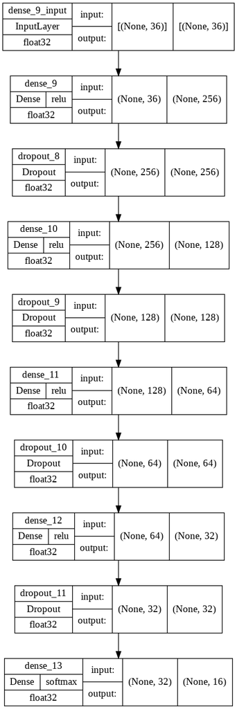

```python
# Generating a figure that shows the structure of the fourth architecture
# This contain input and output size as well as activation functions

tf.keras.utils.plot_model(model_v4,show_shapes=True,
    show_dtype=True,expand_nested=True,show_layer_activations=True, to_file='drive/My Drive/FYP data/model_v4.png')
```

```python
# Saving the trained model of the fourth architecture

model_v4.save('drive/My Drive/FYP data/keras_model_v4.h5')
```

```python
# Performing prediction with the validation dataset
# This data will be used to calculate the evaluation metrics
y_pred_4 = model_v4.predict(X_valid)

# Due to the nature of Soft-Max, probabilities of the output being in a class is used
# This method selects the class with the largest probability
y_pred_4 = np.argmax(y_pred_4, axis=-1)
```

```python
# Calculating the accuracy and recall scores using the predictions from the
# validation dataset

print(accuracy_score(df_validation[' Label'], y_pred_4))
print(recall_score(df_validation[' Label'], y_pred_4, average='macro'))
print(recall_score(df_validation[' Label'], y_pred_4, average='micro'))
print(recall_score(df_validation[' Label'], y_pred_4, average='weighted'))
```

```
0.9749922645095699
0.9091912543844161
0.9749922645095699
0.9749922645095699
```

```python
# Producing the confusion matrix for the fourth architecture

array_multi_4 = multilabel_confusion_matrix(df_validation[' Label'], y_pred_4)
```

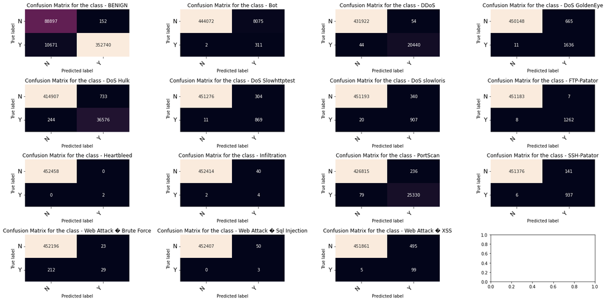

```python
# Generating the figure for the fourth architecture
# Code modified from https://stackoverflow.com/questions/62722416/plot-confusion-matrix-for-multilabel-classifcation-python

vis_arr_4 = np.asarray(array_multi_4)

classes = encoder.classes_

labels = ["".join(classes[i]) for i in range(len(encoder.classes_))]

fig, axis = plt.subplots(4, 4, figsize=(20, 10))

# Generating the confusion matrices for each class
for axes, cf_matrix, label in zip(axis.flatten(), vis_arr_4, labels):
    print_confusion_matrices(cf_matrix, axes, label, ["N", "Y"])

fig.tight_layout()
plt.savefig('drive/My Drive/FYP data/confusion_matrix_model4.png')
plt.show()
```

```python
# Calculating the F1-Score for the fourth architecture

print(f1_score(df_validation[' Label'], y_pred_4, average='macro'))
print(f1_score(df_validation[' Label'], y_pred_4, average='micro'))
print(f1_score(df_validation[' Label'], y_pred_4, average='weighted'))
```

```
0.6809671645132487
0.9749922645095699
0.9836559943356888
```

```python
# Calculating the Precision for the fourth architecture

print(precision_score(df_validation[' Label'], y_pred_4, average='macro'))
print(precision_score(df_validation[' Label'], y_pred_4, average='micro'))
print(precision_score(df_validation[' Label'], y_pred_4, average='weighted'))
```

```
0.6613250970033627
0.9749922645095699
0.9939032361268636
```

```python
# Calculating the Specificity for the fourth architecture

from aif360.sklearn.metrics import specificity_score

specificity_score(df_validation[' Label'], y_pred_4, sample_weight=None)
```

```
0.9821407639550854
```

This section is for the fifth architecture that has been implemented. It containes the training of the model, and the evaluation of it using the metrics.

```python
# This method is used to generate the model using the fifth architecture
# All the layers and their configurations can be seen below
# As well as the loss function used and optimizer

def create_baseline_5():
	model = Sequential()
	model.add(Dense(512, input_dim=36, activation='relu'))
	model.add(Dropout(0.2))
	model.add(Dense(256, activation='relu'))
	model.add(Dropout(0.2))
	model.add(Dense(128, activation='relu'))
	model.add(Dropout(0.2))
	model.add(Dense(64, activation='relu'))
	model.add(Dropout(0.2))
	model.add(Dense(32, activation='relu'))
	model.add(Dropout(0.2))
	model.add(Dense(16, activation='softmax'))
	model.compile(loss='sparse_categorical_crossentropy', optimizer='adam', metrics=['accuracy'])
	return model
```

```python
# The model is generated
# And a comprehensive list of its parameters as well as the parameters
# per layer is generated

model_v5 = create_baseline_5()
model_v5.summary()
```

```
Model: "sequential_4"
_________________________________________________________________
 Layer (type)                Output Shape              Param #
=================================================================
 dense_20 (Dense)            (None, 512)               18944

 dropout_17 (Dropout)        (None, 512)               0

 dense_21 (Dense)            (None, 256)               131328

 dropout_18 (Dropout)        (None, 256)               0

 dense_22 (Dense)            (None, 128)               32896

 dropout_19 (Dropout)        (None, 128)               0

 dense_23 (Dense)            (None, 64)                8256

 dropout_20 (Dropout)        (None, 64)                0

 dense_24 (Dense)            (None, 32)                2080

 dropout_21 (Dropout)        (None, 32)                0

 dense_25 (Dense)            (None, 16)                528

=================================================================
Total params: 194,032
Trainable params: 194,032
Non-trainable params: 0
_________________________________________________________________
```

```python
# Training the fifth architecture model
# Training the model, the inputted data is the training dataset,
# Testing dataset is used to see how well the training is going
# Batch size is 32 and 25 epochs will be used for training

model_v5.fit(X_train, df_oversampled[' Label'], epochs=25, batch_size=32, verbose=1, validation_data=(X_test, df_test[' Label']), callbacks=[early_stop, reduce_lr, early_stop_accuracy])
```

```
Epoch 16: ReduceLROnPlateau reducing learning rate to 0.00020000000949949026.
```

```
<keras.callbacks.History at 0x7f84ded5efd0>
```

```python
# Saving the model generated for the fifth architecture

model_v5.save('drive/My Drive/FYP data/keras_model_v5.h5')
```

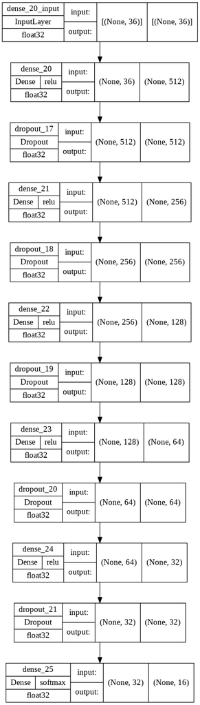

```python
# Generating the figure for the fifth architecture

tf.keras.utils.plot_model(model_v5,show_shapes=True,
    show_dtype=True,expand_nested=True,show_layer_activations=True, to_file='drive/My Drive/FYP data/model_v5.png')
```

```python
# Performing prediction with the validation dataset
# This data will be used to calculate the evaluation metrics
y_pred_5 = model_v5.predict(X_valid)

# Due to the nature of Soft-Max, probabilities of the output being in a class is used
# This method selects the class with the largest probability
y_pred_5 = np.argmax(y_pred_5, axis=-1)
```

```python
# Calculating the accuracy and Recall Score for the fifth architecture

print(accuracy_score(df_validation[' Label'], y_pred_5))
print(recall_score(df_validation[' Label'], y_pred_5, average='macro'))
print(recall_score(df_validation[' Label'], y_pred_5, average='micro'))
print(recall_score(df_validation[' Label'], y_pred_5, average='weighted'))
```

```
0.9734142244618309
0.9087939896302886
0.9734142244618309
0.9734142244618309
```

```python
# Generating the confusion matrix for the fifth architecture

array_multi_5 = multilabel_confusion_matrix(df_validation[' Label'], y_pred_5)
```

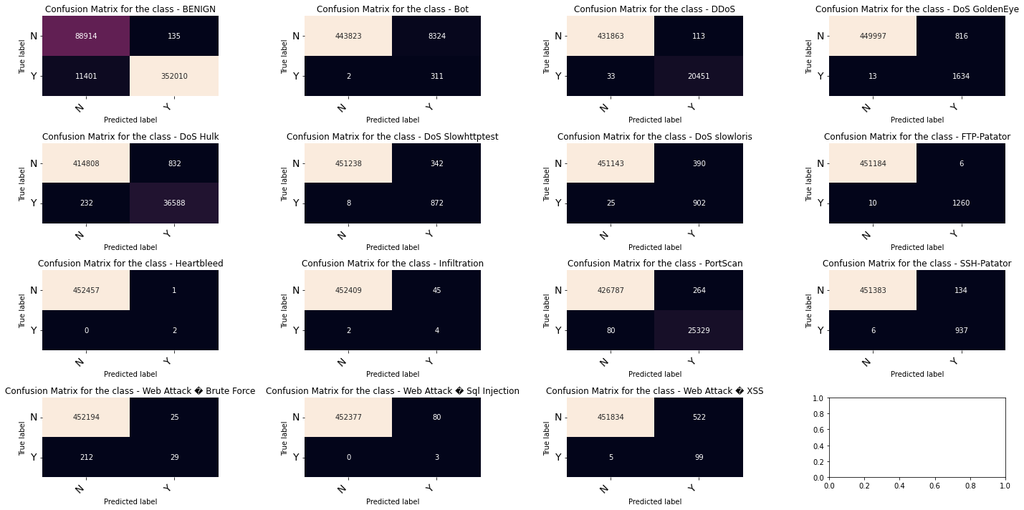

```python
# Generating the figure for the confusion matrix of the fifth architecture
# Code modified from https://stackoverflow.com/questions/62722416/plot-confusion-matrix-for-multilabel-classifcation-python

vis_arr_5 = np.asarray(array_multi_5)

classes = encoder.classes_

labels = ["".join(classes[i]) for i in range(len(encoder.classes_))]

fig, axis = plt.subplots(4, 4, figsize=(20, 10))

# Generating the confusion matrix for each class
for axes, cf_matrix, label in zip(axis.flatten(), vis_arr_5, labels):
    print_confusion_matrices(cf_matrix, axes, label, ["N", "Y"])

fig.tight_layout()
plt.savefig('drive/My Drive/FYP data/confusion_matrix_model5.png')
plt.show()
```

```python
# Calculating the F1-Score for the fifth architecture

print(f1_score(df_validation[' Label'], y_pred_5, average='macro'))
print(f1_score(df_validation[' Label'], y_pred_5, average='micro'))
print(f1_score(df_validation[' Label'], y_pred_5, average='weighted'))
```

```
0.6587574626641842
0.973414224461831
0.9824806512595432
```

```python
# Calculating the precision score for the fifth architrcture

print(precision_score(df_validation[' Label'], y_pred_5, average='macro'))
print(precision_score(df_validation[' Label'], y_pred_5, average='micro'))
print(precision_score(df_validation[' Label'], y_pred_5, average='weighted'))
```

```
0.6288000939692687
0.9734142244618309
0.9932751708183468
```

```python
# Calculating the specificity score for the fifth architecture

from aif360.sklearn.metrics import specificity_score

specificity_score(df_validation[' Label'], y_pred_5, sample_weight=None)
```

```
0.9815900581005735
```

This is the Improved Initial architecture with removed foutput layer. That means that all the layers are the same except that the final layer has been removed.

In this section, the method used to generate the model as well as training and evaluation can be found.

```python
# The method used to generate the Improved initial architecture
# without output layer
# Tha layers and their settings can be seen below

def create_baseline_32end():
	model = Sequential()
	model.add(Dense(128, input_dim=36, activation='relu'))
	model.add(Dropout(0.2))
	model.add(Dense(64, activation='relu'))
	model.add(Dropout(0.2))
	model.add(Dense(32, activation='softmax'))
	model.compile(loss='sparse_categorical_crossentropy', optimizer='adam', metrics=['accuracy'])
	return model
```

```python
# The model is generated
# And a comprehensive list of its parameters as well as the parameters
# per layer is generated

model_baseline_shortend = create_baseline_32end()
model_baseline_shortend.summary()
```

```
Model: "sequential"
_________________________________________________________________
 Layer (type)                Output Shape              Param #
=================================================================
 dense (Dense)               (None, 128)               4736

 dropout (Dropout)           (None, 128)               0

 dense_1 (Dense)             (None, 64)                8256

 dropout_1 (Dropout)         (None, 64)                0

 dense_2 (Dense)             (None, 32)                2080

=================================================================
Total params: 15,072
Trainable params: 15,072
Non-trainable params: 0
_________________________________________________________________
```

```python
# The model training happens here
# Training the model, the inputted data is the training dataset,
# Testing dataset is used to see how well the training is going
# Batch size is 32 and 25 epochs will be used for training


model_baseline_shortend.fit(X_train, df_oversampled[' Label'], epochs=25, batch_size=32, verbose=1, validation_data=(X_test, df_test[' Label']), callbacks=[early_stop, reduce_lr, early_stop_accuracy])
```

```
Epoch 15: ReduceLROnPlateau reducing learning rate to 0.00020000000949949026.
Epoch 20: ReduceLROnPlateau reducing learning rate to 4.0000001899898055e-05.
Epoch 25: ReduceLROnPlateau reducing learning rate to 8.000000525498762e-06.
```

```
<keras.callbacks.History at 0x7f77d54c5690>
```

```python
# Saving the trained model for future use

model_baseline_shortend.save('drive/My Drive/FYP data/keras_model_shortend.h5')
```

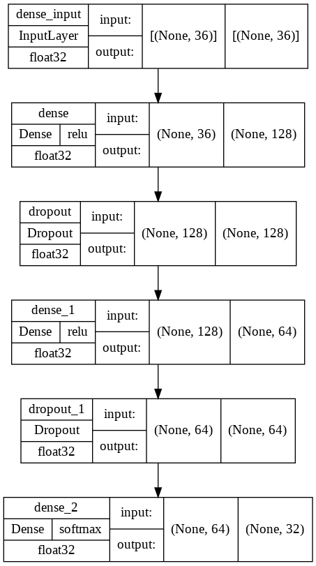

```python
# Generating the figure for the fifth architecture

tf.keras.utils.plot_model(model_baseline_shortend,show_shapes=True,
    show_dtype=True,expand_nested=True,show_layer_activations=True, to_file='drive/My Drive/FYP data/model_shorthend.png')
```

```python
# Performing prediction with the validation dataset
# This data will be used to calculate the evaluation metrics
y_pred_6 = model_baseline_shortend.predict(X_valid)

# Due to the nature of Soft-Max, probabilities of the output being in a class is used
# This method selects the class with the largest probability
y_pred_6 = np.argmax(y_pred_6, axis=-1)
```

```python
# Calculating the accuracy and recall scores for
# the Improved initial architecture without output layer

print(accuracy_score(df_validation[' Label'], y_pred_6))
print(recall_score(df_validation[' Label'], y_pred_6, average='macro'))
print(recall_score(df_validation[' Label'], y_pred_6, average='micro'))
print(recall_score(df_validation[' Label'], y_pred_6, average='weighted'))
```

```
0.976170269195067
0.8857997125656482
0.976170269195067
0.976170269195067
```

```python
# Calculating the precision score for
# the Improved initial architecture without output layer

print(precision_score(df_validation[' Label'], y_pred_6, average='macro'))
print(precision_score(df_validation[' Label'], y_pred_6, average='micro'))
print(precision_score(df_validation[' Label'], y_pred_6, average='weighted'))
```

```
0.6529612123658391
0.976170269195067
0.9935052875175769
```

```python
# Calculating the F1-Score for
# the Improved initial architecture without output layer

print(f1_score(df_validation[' Label'], y_pred_6, average='macro'))
print(f1_score(df_validation[' Label'], y_pred_6, average='micro'))
print(f1_score(df_validation[' Label'], y_pred_6, average='weighted'))
```

```
0.6716067392285794
0.976170269195067
0.9840053175004772
```

```python
# Calculating the Specificity score for
# the Improved initial architecture without output layer

from aif360.sklearn.metrics import specificity_score

specificity_score(df_validation[' Label'], y_pred_6, sample_weight=None)
```

```
0.9841533837446671
```

```python
# Calculating multi-label confusion matrix for
# the Improved initial architecture without output layer

array_multi_6 = multilabel_confusion_matrix(df_validation[' Label'], y_pred_6)
```

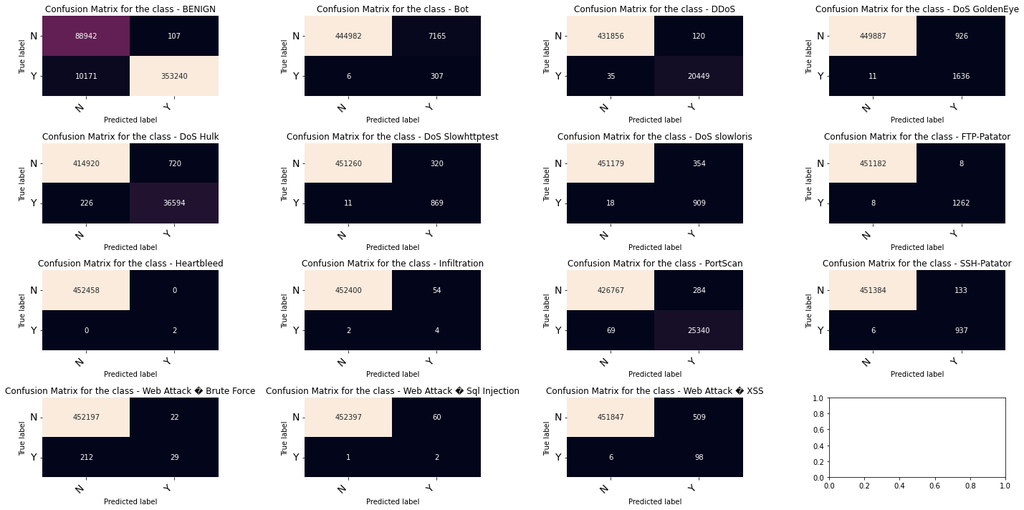

```python
# Generating the figure for the confusion matrix
# Code modified from https://stackoverflow.com/questions/62722416/plot-confusion-matrix-for-multilabel-classifcation-python

vis_arr_6 = np.asarray(array_multi_6)

classes = encoder.classes_

labels = ["".join(classes[i]) for i in range(len(encoder.classes_))]

fig, axis = plt.subplots(4, 4, figsize=(20, 10))

# Generating the confusion matrix for each class
for axes, cf_matrix, label in zip(axis.flatten(), vis_arr_6, labels):
    print_confusion_matrices(cf_matrix, axes, label, ["N", "Y"])

fig.tight_layout()
plt.savefig('drive/My Drive/FYP data/confusion_matrix_model6.png')
plt.show()
```

This is the last architecture that was proposed. A different version of the initial architecture where the first layer was removed. It was not evaluated as its performance was not improving during training.

```python
# The method used to generate the Improved initial architecture
# without input layer
# Tha layers and their settings can be seen below

def create_baseline_16end_no_start():
	model = Sequential()
	model.add(Dense(64, input_dim=36,activation='relu'))
	model.add(Dropout(0.2))
	model.add(Dense(32, activation='relu'))
	model.add(Dropout(0.2))
	model.add(Dense(16, activation='softmax'))
	model.compile(loss='sparse_categorical_crossentropy', optimizer='adam', metrics=['accuracy'])
	return model
```

```python
# The model is generated
# And a comprehensive list of its parameters as well as the parameters
# per layer is generated

model_baseline_shortstart = create_baseline_16end_no_start()
model_baseline_shortstart.summary()
```

```
Model: "sequential_4"
_________________________________________________________________
 Layer (type)                Output Shape              Param #
=================================================================
 dense_12 (Dense)            (None, 64)                2368

 dropout_8 (Dropout)         (None, 64)                0

 dense_13 (Dense)            (None, 32)                2080

 dropout_9 (Dropout)         (None, 32)                0

 dense_14 (Dense)            (None, 16)                528

=================================================================
Total params: 4,976
Trainable params: 4,976
Non-trainable params: 0
_________________________________________________________________
```

```python
# Training the generated model for the new architecture
# Training the model, the inputted data is the training dataset,
# Testing dataset is used to see how well the training is going
# Batch size is 32 and 25 epochs will be used for training

model_baseline_shortstart.fit(X_train, df_oversampled[' Label'], epochs=25, batch_size=32, verbose=1, validation_data=(X_test, df_test[' Label']), callbacks=[early_stop, reduce_lr, early_stop_accuracy])
```

```
Epoch 5: ReduceLROnPlateau reducing learning rate to 0.00020000000949949026.
Epoch 10: ReduceLROnPlateau reducing learning rate to 4.0000001899898055e-05.
Epoch 15: ReduceLROnPlateau reducing learning rate to 8.000000525498762e-06.
Restoring model weights from the end of the best epoch: 12.
Epoch 17: early stopping
Epoch 17: early stopping
```

```
<keras.callbacks.History at 0x7f77d4ee1b50>
```

```python
# Saving the trained model of the Improved initial architecture
# without input layer

model_baseline_shortstart.save('drive/My Drive/FYP data/keras_model_shortstart.h5')
```